# Exercise - some linear models part 1

Author

Søren Højsgaard

Published

February 25, 2025

## 1 Useful packages

```r
library(doBy)
library(ggplot2)
library(broom)
library(palmerpenguins)
library(dplyr)
library(patchwork)
```

## 2 Mating songs of male crickets

Walker (1962) studied the mating songs of male tree crickets. Each wingstroke by a cricket produces a pulse of song, and females may use the number of pulses per second to identify males of the correct species. Walker (1962) wanted to know whether the chirps of the crickets Oecanthus exclamationis (abbreviated exis) and Oecanthus niveus (abbreviated nius) had different pulse rates. See https://www.biostathandbook.com/ for details. (The abbreviations are made from the the first two and last two letters of the species.) He measured the pulse rate of the crickets (variable ‘pps’) at a variety of temperatures (‘temp’):

```r
crickets |> head(3)
crickets |> tail(3)
```

[output not shown]

### 2.1 Task

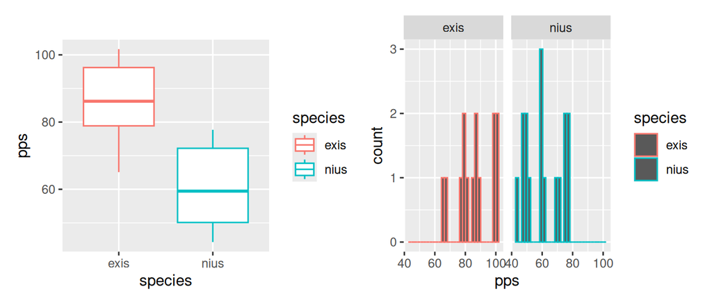

```r
pl1 <- crickets |> ggplot(aes(x=species, y=pps, color=species)) +
    geom_boxplot()
pl2 <- crickets |> ggplot(aes(x=pps, color=species)) +
    geom_histogram() + facet_grid(~species)
pl1 + pl2
```

1. Consider these plots. They suggest a very simple linear model for comparing the species (hint: think anova). Create such a model. Sanity check: You should find that the difference in `pps` is around $25$.
2. Create diagnostic plots of the model. Anything you worry about in the diagnostic plots?

### 2.2 Task

1. Create dataset `crickets2` containing data points where temp is larger than 20 and smaller than 27 (the reason for these limits become clear below).
2. Produce the plot below.
3. Redo the steps above on this subset of data. Sanity check: You should find that the difference in `pps` is around $11$.
4. What do you make of the estimated difference in pps now compared with the results above?

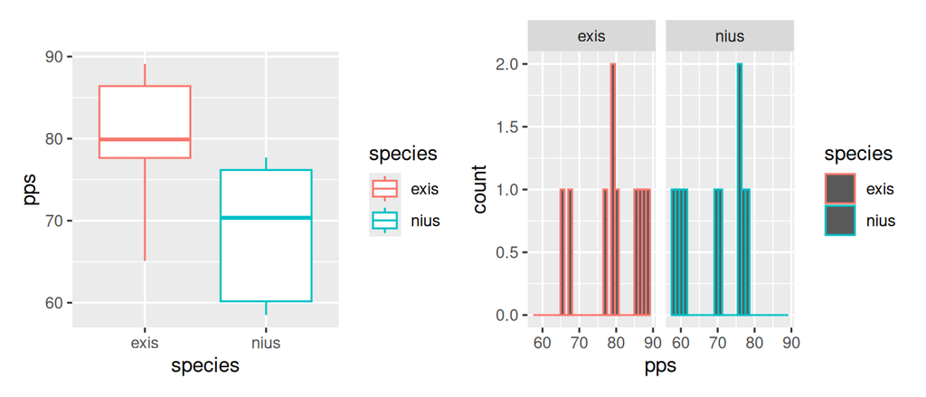

### 2.3 Task

1. Create the plot below based on all data.
2. Can you see why we focused only on data points where temp is between 20 and 27?
3. This plot should inspire you to a model (hint: think ancova).
4. What is the estimated difference in pps for the species?

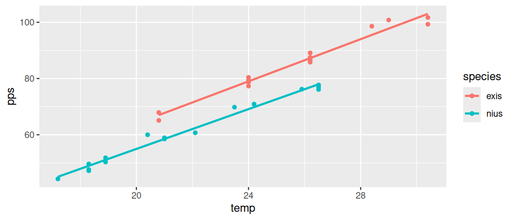